# Mann-Whitney-U-Test

## Packages

```r
library(dplyr)# -> Deskriptive Statistik Variante 1
library(psych)# -> Deskriptive Statistik Variante 2
library(ggplot2)# -> Diagramme Variante 2
library(exactRankTests)#-> U-Test
```

## Roadmap

1. Hypothese
2. Voraussetzungen des Mann-Whitney-U-Tests
3. Grundlegende Konzepte
4. Deskriptive Statistik
5. Boxplot
6. Ergebnisse des Mann-Whitney-U-Tests
7. Berechnung der Effektstärke
8. Eine Aussage

# Hypothese

H1: Es gibt einen Unterschied in der Entscheidungsbeurteilung zwischen der Bauch und Kopf.

H0: Es gibt keinen Unterschied in der Entscheidungsbeurteilung zwischen der Bauch und Kopf.

# Voraussetzungen des Mann-Whitney-U-Tests

Die abhängige Variable ist mindestens ordinalskaliert -> Entscheidungsbeurteilung wurde nur einmal erfragt. Es handelt sich um eine sub. Einschätzung.

Es liegt eine unabhängige Variable vor, mittels der die beiden zu vergleichenden Gruppen gebildet werden. -> Bauch vs Kopf

Bei diesen Ausprägungen eignet sich der U-Test:

- kleine Stichproben
- Ausreisser
- ordinalskalierte Daten
- keine Normalverteilung

# Grundlegende Konzepte

Der Mann-Whitney-U-Test für unabhängige Stichproben wird auch “Wilcoxon Rangsummen-Test” (engl. “Wilcoxon rank-sum test”, kurz: WRS) genannt. Er testet, ob die zentralen Tendenzen zweier unabhängiger Stichproben verschieden sind.Der Mann-Whitney-U-Test ist die nichtparametrische Alternative für den t-Test für unabhängige Stichproben, wenn die Voraussetzungen nicht erfüllt sind.

# Deskriptive Statistik

### Variante 1

```r
#library(dplyr)

uebung6 %>%
group_by(KopfODERBauch) %>% #Gruppierung
  summarize(Anzahl = n(), Median = median(Beurteilung)) %>%
  mutate_if(is.numeric, round, 2)# Runden nach der zweiten Kommastelle und die Zahl als nummerisch klassifizieren
```

| KopfODERBauch | Anzahl | Median |
| --- | --- | --- |
| Bauch | 11 | 10.0 |
| Kopf | 8 | 4.5 |

### Variante 2

```r
#library(psych)

describe.by(uebung6$Beurteilung, group = uebung6$KopfODERBauch, mat = TRUE)
```

```
describe.by is deprecated.  Please use the describeBy function
```

|  | item | group1 | vars | n | mean | sd | median | trimmed | mad | min | max | range | skew | kurtosis | se |
| --- | --- | --- | --- | --- | --- | --- | --- | --- | --- | --- | --- | --- | --- | --- | --- |
| X11 | 1 | Bauch | 1 | 11 | 9.818182 | 3.092513 | 10.0 | 9.777778 | 2.9652 | 5 | 15 | 10 | 0.1359576 | -1.185869 | 0.9324277 |
| X12 | 2 | Kopf | 1 | 8 | 5.000000 | 2.390457 | 4.5 | 5.000000 | 2.9652 | 2 | 8 | 6 | 0.1647174 | -1.882187 | 0.8451543 |

# Boxplot

### Variante 1

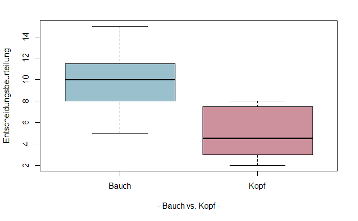

```r
Farben <- c("lightblue3", "pink3")

boxplot(uebung6$Beurteilung ~  uebung6$KopfODERBauch,
    col=Farben,
    ylab="Entscheidungsbeurteilung" , xlab="- Bauch vs. Kopf -")
```

### Variante 2

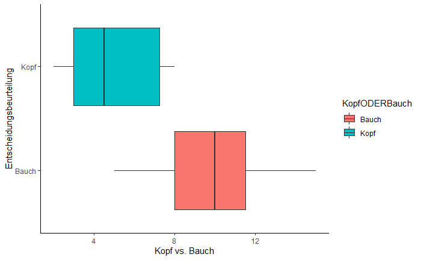

```r
#library(ggplot2)
ggplot(uebung6, # Datensatz
       aes(x =Beurteilung, # AV
           y = KopfODERBauch)) + # UV
  geom_boxplot(aes(fill = KopfODERBauch)) + # Aufteilung für Legende und das ein Boxplot erstellt werden soll
  theme_classic()+ # Farbschema
  labs(y="Entscheidungsbeurteilung", x = "Kopf vs. Bauch")#Labels
```

Es gibt einen Unterschied in der zentralen Tendenz. Keine Ausreißer.

**Hinweis:** Die Boxplot werden unterschiedlich berechnet. Weierführende Informationen unter: Statistik mit Jule-> Diagramme -> Boxplots